# Introduction to Decision Tree and Random Forest Intuition

## Outcomes

- Explain how a decision tree functions and how to build one
- Visually represent a decision tree
- Determine when using a decision tree is an appropriate method

## Sample Decision Tree

### Iris Dataset

[figure not shown]

Three types of iris we are classifying (above)

```python
"""
Run this code, do not change anything
"""
import pandas as pd
import numpy as np
import matplotlib.pyplot as plt
from sklearn import datasets
```

```python
"""
Run this code, do not change anything
"""
iris =  datasets.load_iris()
x = pd.DataFrame(iris.data, columns=iris.feature_names)
y = pd.DataFrame(iris.target, columns=['iris_type'])
```

[figure not shown]

We have the dimensions of the petal and sepal (above)

```python
"""
Run this code to see dataset
"""
iris_dict = {0: 'setosa', 1: 'versicolor', 2:'virginica'}
target_labels = [iris_dict.get(t) for t in y['iris_type']]
features = x
features['targets'] = target_labels
features
```

|  | sepal length (cm) | sepal width (cm) | petal length (cm) | petal width (cm) | targets |
| --- | --- | --- | --- | --- | --- |
| 0 | 5.1 | 3.5 | 1.4 | 0.2 | setosa |
| 1 | 4.9 | 3.0 | 1.4 | 0.2 | setosa |
| 2 | 4.7 | 3.2 | 1.3 | 0.2 | setosa |
| 3 | 4.6 | 3.1 | 1.5 | 0.2 | setosa |
| 4 | 5.0 | 3.6 | 1.4 | 0.2 | setosa |
| 5 | 5.4 | 3.9 | 1.7 | 0.4 | setosa |
| 6 | 4.6 | 3.4 | 1.4 | 0.3 | setosa |
| 7 | 5.0 | 3.4 | 1.5 | 0.2 | setosa |
| 8 | 4.4 | 2.9 | 1.4 | 0.2 | setosa |
| 9 | 4.9 | 3.1 | 1.5 | 0.1 | setosa |
| 10 | 5.4 | 3.7 | 1.5 | 0.2 | setosa |
| 11 | 4.8 | 3.4 | 1.6 | 0.2 | setosa |
| 12 | 4.8 | 3.0 | 1.4 | 0.1 | setosa |
| 13 | 4.3 | 3.0 | 1.1 | 0.1 | setosa |
| 14 | 5.8 | 4.0 | 1.2 | 0.2 | setosa |
| 15 | 5.7 | 4.4 | 1.5 | 0.4 | setosa |
| 16 | 5.4 | 3.9 | 1.3 | 0.4 | setosa |
| 17 | 5.1 | 3.5 | 1.4 | 0.3 | setosa |
| 18 | 5.7 | 3.8 | 1.7 | 0.3 | setosa |
| 19 | 5.1 | 3.8 | 1.5 | 0.3 | setosa |
| 20 | 5.4 | 3.4 | 1.7 | 0.2 | setosa |
| 21 | 5.1 | 3.7 | 1.5 | 0.4 | setosa |
| 22 | 4.6 | 3.6 | 1.0 | 0.2 | setosa |
| 23 | 5.1 | 3.3 | 1.7 | 0.5 | setosa |
| 24 | 4.8 | 3.4 | 1.9 | 0.2 | setosa |
| 25 | 5.0 | 3.0 | 1.6 | 0.2 | setosa |
| 26 | 5.0 | 3.4 | 1.6 | 0.4 | setosa |
| 27 | 5.2 | 3.5 | 1.5 | 0.2 | setosa |
| 28 | 5.2 | 3.4 | 1.4 | 0.2 | setosa |
| 29 | 4.7 | 3.2 | 1.6 | 0.2 | setosa |
| ... | ... | ... | ... | ... | ... |
| 120 | 6.9 | 3.2 | 5.7 | 2.3 | virginica |
| 121 | 5.6 | 2.8 | 4.9 | 2.0 | virginica |
| 122 | 7.7 | 2.8 | 6.7 | 2.0 | virginica |
| 123 | 6.3 | 2.7 | 4.9 | 1.8 | virginica |
| 124 | 6.7 | 3.3 | 5.7 | 2.1 | virginica |
| 125 | 7.2 | 3.2 | 6.0 | 1.8 | virginica |
| 126 | 6.2 | 2.8 | 4.8 | 1.8 | virginica |
| 127 | 6.1 | 3.0 | 4.9 | 1.8 | virginica |
| 128 | 6.4 | 2.8 | 5.6 | 2.1 | virginica |
| 129 | 7.2 | 3.0 | 5.8 | 1.6 | virginica |
| 130 | 7.4 | 2.8 | 6.1 | 1.9 | virginica |
| 131 | 7.9 | 3.8 | 6.4 | 2.0 | virginica |
| 132 | 6.4 | 2.8 | 5.6 | 2.2 | virginica |
| 133 | 6.3 | 2.8 | 5.1 | 1.5 | virginica |
| 134 | 6.1 | 2.6 | 5.6 | 1.4 | virginica |
| 135 | 7.7 | 3.0 | 6.1 | 2.3 | virginica |
| 136 | 6.3 | 3.4 | 5.6 | 2.4 | virginica |
| 137 | 6.4 | 3.1 | 5.5 | 1.8 | virginica |
| 138 | 6.0 | 3.0 | 4.8 | 1.8 | virginica |
| 139 | 6.9 | 3.1 | 5.4 | 2.1 | virginica |
| 140 | 6.7 | 3.1 | 5.6 | 2.4 | virginica |
| 141 | 6.9 | 3.1 | 5.1 | 2.3 | virginica |
| 142 | 5.8 | 2.7 | 5.1 | 1.9 | virginica |
| 143 | 6.8 | 3.2 | 5.9 | 2.3 | virginica |
| 144 | 6.7 | 3.3 | 5.7 | 2.5 | virginica |
| 145 | 6.7 | 3.0 | 5.2 | 2.3 | virginica |
| 146 | 6.3 | 2.5 | 5.0 | 1.9 | virginica |
| 147 | 6.5 | 3.0 | 5.2 | 2.0 | virginica |
| 148 | 6.2 | 3.4 | 5.4 | 2.3 | virginica |
| 149 | 5.9 | 3.0 | 5.1 | 1.8 | virginica |

150 rows × 5 columns

### Prepare the data

```python
"""
Run this code to prepare the data for modelling
"""
# Split into training validation and test
x = iris.data
y = iris.target
from sklearn.model_selection import StratifiedShuffleSplit

# Split the data into train=80%, test=10% and valid=10%
ss = StratifiedShuffleSplit(n_splits=1, test_size=0.2)
splitter = ss.split(x, y)

for train_index, temp_index in splitter:
    #print("TRAIN:", train_index, "TEST:", test_index)
    train_x, train_y  = x[train_index], y[train_index]
    temp_x, temp_y  = x[temp_index], y[temp_index]

# Again for test and valid set, this time 50-50
ss = StratifiedShuffleSplit(n_splits=1, test_size=0.5)
splitter = ss.split(temp_x, temp_y)

for test_index, valid_index in splitter:
    #print("TRAIN:", train_index, "TEST:", test_index)
    test_x, test_y  = temp_x[test_index], temp_y[test_index]
    val_x, val_y    = temp_x[valid_index], temp_y[valid_index]

print('Done')
```

```
Done
```

```python
print('Training shape',train_x.shape )
print('Testing shape',test_x.shape)
print('Validation shape',val_x.shape)
```

```
Training shape (120, 4)
Testing shape (15, 4)
Validation shape (15, 4)
```

### Train the model

```python
# Build Tree
from sklearn import tree
clf = tree.DecisionTreeClassifier(max_depth=2)
clf = clf.fit(train_x, train_y)
```

```python
# with open("iris.dot", 'w') as f:
#     f = tree.export_graphviz(clf, out_file=f)
```

### Plot Decision Tree

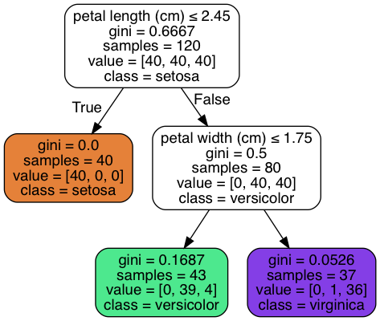

```python
from IPython.display import Image
dot_data = tree.export_graphviz(clf, out_file=None,
                     feature_names=iris.feature_names,
                     class_names=iris.target_names,
                     filled=True, rounded=True,
                     special_characters=True)
graph = pydotplus.graph_from_dot_data(dot_data)
Image(graph.create_png())
```

```python
from sklearn.metrics import accuracy_score
predictions = clf.predict(val_x)
acc = accuracy_score(val_y, predictions)
print('Accuracy on Validation set =', acc)
```

```
Accuracy on Validation set = 1.0
```

```python
predictions = clf.predict(test_x)
acc = accuracy_score(test_y, predictions)
print('Accuracy on Test set =', acc)
```

```
Accuracy on Test set = 0.933333333333
```

```python
from sklearn.metrics import classification_report
print(classification_report(val_y, predictions, target_names=iris.target_names))
```

[output not shown]

## Let's look at another example

Will Jonny play tennis on a particular day? Give the attributes of weather outlook, temperature, humidity, and wind strength Jonny makes a decision whether he will play tennis or not. Can we predict his decision?

```python
train = pd.read_csv('data/play_tennis.csv')
info = pd.read_csv('data/play_tennis_info.csv')
```

```python
info
```

|  | Attribute | Possible Values |
| --- | --- | --- |
| 0 | Outlook | sunny, overcast, rain |
| 1 | Temperature | hot, mild, cool |
| 2 | Humidity | high, normal |
| 3 | Windy | true, false |
| 4 | Decision | n(negative), p(positive) |

### Training Data

```python
train
```

|  | Outlook | Temperature | Humidity | Windy | Decision |
| --- | --- | --- | --- | --- | --- |
| 0 | sunny | hot | high | False | n |
| 1 | sunny | hot | high | True | n |
| 2 | overcast | hot | high | False | p |
| 3 | rain | mild | high | False | p |
| 4 | rain | cool | normal | False | p |
| 5 | rain | cool | normal | True | n |
| 6 | overcast | cool | normal | True | p |
| 7 | sunny | mild | high | False | n |
| 8 | sunny | cool | normal | False | p |
| 9 | rain | mild | normal | False | p |
| 10 | sunny | mild | normal | True | p |
| 11 | overcast | mild | high | True | p |
| 12 | overcast | hot | normal | False | p |
| 13 | rain | mild | high | True | n |

[figure not shown]

Decision Tree

[figure not shown]

Youtube Link: https://youtu.be/eKD5gxPPeY0

[figure not shown]

Youtube Link: https://youtu.be/eKD5gxPPeY0

This information was sourced from http://www.cse.unsw.edu.au/~cs9417ml/DT1/

### Prepare Data

```python
x = train.drop('Decision', axis=1)
y = train['Decision']

x_dummies = pd.get_dummies(x)
classes = y.unique()
features = list(x_dummies)
```

### Build model

```python
clf = tree.DecisionTreeClassifier(max_depth=2)
clf = clf.fit(x_dummies, y)
```

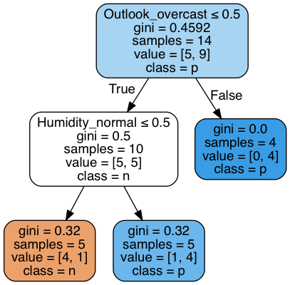

```python
from IPython.display import Image
dot_data = tree.export_graphviz(clf, out_file=None,
                                feature_names=features,
                                class_names=classes,
                                filled=True, rounded=True,
                                special_characters=True)
graph = pydotplus.graph_from_dot_data(dot_data)
Image(graph.create_png())
```

### Decision Tree Algorithm

**Split (node, {examples} ):**

1. A <— the best attribute for splitting the {examples}
2. Decision attribute for this node <— A
3. For each value of A, create new child node
4. Split training {examples} to child nodes
5. For each child node:  
   a) if subset is pure: STOP  
   b) else: Split (child node, (subset)

### When to use a decision tree?

Decision trees are very powerful in situations where you need to be able to explain and visualise why a model is predicting a certain outcome. This is because they make logical IF...THEN...ELSE flows that can account for most of the variability in the data, which can be easily visualised in a dendegram (decision tree). This advantage is generally true for both classification and regression. For a better understanding of when to use a decision tree see the adavntages and disadvantages below.

### Advantages

- Decision trees can be easily used for classification or regression
- They can fit both linear and non-linear problems
- Easy to understand and interpret for people making them useful in a business context. e.g. if this then do that
- They are transparent in their operation meaning that you can trace an outcome back through the model to understand how the model arrived at the outcome. This is unlike other types of models like neural networks where they are black boxes, making them very hard to understand how they are working
- They require little data preparation compared to other models (no scaling or normalisation needed)
- They are moderately computationally expensive when compared to algorithms like gradient boosted trees or deep learning
- Not as sensitive to missing values as other models
- Not as sensitive to outliers in the data

### Disadvantages

- Prone to overfitting the data without proper pruning or limiting tree growth
- Instability: if the training data is perturbed slightly, this can lead to a drastically different model
- They use naive decision boundaries as they run parallel to the X and Y axes (e.g. a diagonal decision boundary may fit better?)

These disadvantages can be largely overcome by combining many decision trees together in a process known as ensembling which leads us to the topic of **random forests**.

## Random Forests

- Trains many decision trees (called weak learners) based on different subsets of the data and features
- Subsets are made by randomly selecting around 66% of the records
- Out of this subset features (columns) are randomly selected so that each tree has a different set of input records and columns

[figure not shown]

Random Forest Example

**Random Forest Algorithm**

1. Sample N cases at random with replacement to create a subset of the data (see top layer of figure above). The subset should be about 66% of the total set.
2. At each node:  
   a) For some number m, m predictor variables are selected at random from all the predictor variables.  
   b) The predictor variable that provides the best split, according to some objective function, is used to do a binary split on that node.  
   c) At the next node, choose another m variables at random from all predictor variables and do the same.

### Making a prediciton

When making a prediction each of the trees makes a predition on the class and the class with the majority of votes is selected to be the correct outcome.

[figure not shown]

Random Forest Example

### Advantages

Random forest runtimes are general fast, and they are able to deal with unbalanced and missing data.

### Disadvantages

Random Forest weaknesses are that when used for regression they cannot predict beyond the range in the training data, and that they may over-fit data sets that are particularly noisy.

### Build a model

```python
from sklearn.ensemble import RandomForestClassifier

clf = RandomForestClassifier(n_estimators=25)
clf.fit(train_x, train_y)

from sklearn.metrics import accuracy_score
predictions = clf.predict(val_x)
acc = accuracy_score(val_y, predictions)
print('Accuracy on Validation set =', acc)

predictions = clf.predict(test_x)
acc = accuracy_score(test_y, predictions)
print('Accuracy on Test set =', acc)
```

```
Accuracy on Validation set = 1.0
Accuracy on Test set = 0.933333333333
```

### Visualise First 3 of 25 Trees

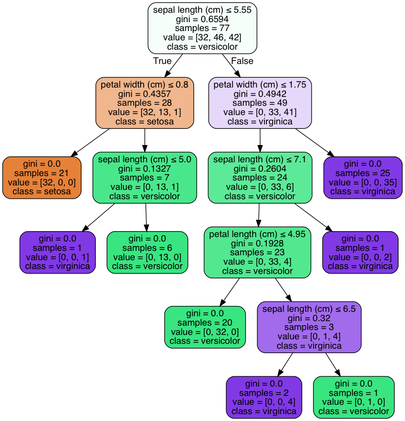

```python
# Visualise Tree 0
from IPython.display import Image
tree_n = 0
dot_data = tree.export_graphviz(clf.estimators_[tree_n], out_file=None,
                     feature_names=iris.feature_names,
                     class_names=iris.target_names,
                     filled=True, rounded=True,
                     special_characters=True)
graph = pydotplus.graph_from_dot_data(dot_data)
Image(graph.create_png())
```

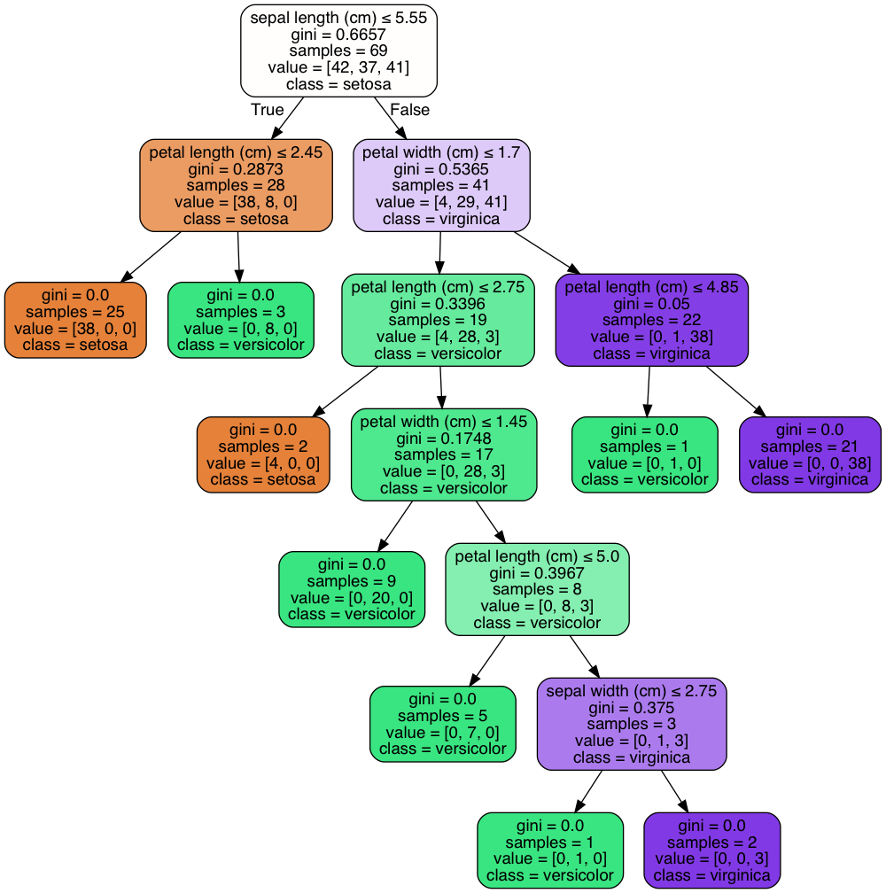

```python
# Visualise Tree 1
tree_n = 1
dot_data = tree.export_graphviz(clf.estimators_[tree_n], out_file=None,
                     feature_names=iris.feature_names,
                     class_names=iris.target_names,
                     filled=True, rounded=True,
                     special_characters=True)
graph = pydotplus.graph_from_dot_data(dot_data)
Image(graph.create_png())
```

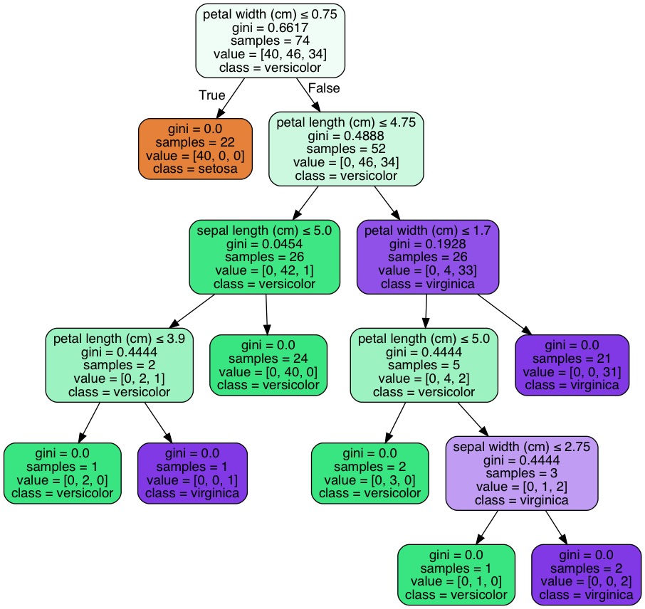

```python
# Visualise Tree 2
tree_n = 2
dot_data = tree.export_graphviz(clf.estimators_[tree_n], out_file=None,
                     feature_names=iris.feature_names,
                     class_names=iris.target_names,
                     filled=True, rounded=True,
                     special_characters=True)
graph = pydotplus.graph_from_dot_data(dot_data)
Image(graph.create_png())
```

## TEST YOUR KNOWLEDGE

Open the file Student Copy.ipynb in the repository and fill in the sections labelled with 'TO DO' to test your knowledge of this decision trees and random forests.

[figure not shown]

Random Forest Example